# DST Update

Bill

April

Hi guys, the purpose of this document is to let you know where I’m at with the DST project, and update you on any plans. It’s divided into three main sections:

1. The available options for graph analysis with Spark, and how to get `pyspark` running with `graphframes` in Jupyter.
2. The graphs we can construct from the insider threats data, and analyses we might want to pursue.
3. Discussion of parallel algorithms on graphs.

### Section 1

The possible options for graph analysis with Spark are ‘GraphX’ and ‘GraphFrames’. Our initial intention was to use ‘Pregel’ but this is proprietary.

#### 1.1 GraphX

GraphX extends Spark’s Resilient Distributed Dataset (RDD) abstraction to a ‘Graph’ abstraction, allowing fast working graph algorithms. For the purposes of our project however GraphX has two major disadvantages:

1. The only API currently supported is in Scala, none of us know Scala well and have little time to learn.
2. I can’t for the life of me get GraphX working in Jupyter, even if we did bite the bullet with regard to Scala.

#### 1.2 GraphFrames

GraphFrames is a Spark package which extends Spark’s DataFrame abstraction (instead of GraphX extending RDDs). Spark DataFrames have more functionality than RDDs and the idea is that this extra flexibility can be leveraged for even more optimised computations on graphs, and much better graph queries. Better yet there is a Python API for GraphFrames and it works in jupyter. I will describe how to get this up and running in **1.3**.

It’s worth noting that there it is possible to use Spark with R, the interface is very neat using the `sparklyr` package and it’s extremely easy to get working. The only option for Spark graph analysis in R is the `graphframes` package. I wasted multiple days with this before realising it’s way too limiting for our project. The R `graphframes` package simply wraps the most used commonly used algorithms in GraphFrames, offering no ‘programability’ beyond the wrapped algorithms, and adding an extra obscuring layer when trying to understand how the computation is being carried out.

#### 1.3 GraphFrames in Jupyter

It’s a bit of a pain to get Spark packages working, and I couldn’t get them working within a `conda` environment (very weird), but I’ve at least got something which works for me. First download Spark with some shell along the lines of:

`brew install apache-spark`

To find out where spark has been installed use:

`brew info apache-spark`

In my case this was `/usr/local/Cellar/apache-spark/3.2.1`. Now to get our jupyter instance running try the following shell:

`export PYSPARK_DRIVER_PYTHON=jupyter`

`export PYSPARK_DRIVER_PYTHON_OPTS=notebook`

`/usr/local/Cellar/apache-spark/3.2.1/bin/pyspark --packages graphframes:graphframes:0.8.2-spark3.2-s_2.12`

Where you modify the path accordingly, the `/bin/pyspark` part of the path refers to the pyspark executable. The `graphframes:0.8.2-spark3.2-s_2.12` part of the above shell may need to be adapted depending on which version of Spark you have installed and which versions of GraphFrames are compatible. To see the list of the possible options check here:

https://spark-packages.org/package/graphframes/graphframes

The above shell should open up a jupyter instance in which Spark with GraphFrames is working, and if it does work it’s convenient to make a shell script so you don’t have to retype it each time.

### Section 2

We now go on to discuss what graphs naturally arise from the insider threats data in **2.1**, and analyses we might want to try out with GraphFrames in **2.2**.

#### 2.1 Graphs We Can Make

We can construct and abundance of graphs from the insider threats data. These are the following graphs I’ve been playing with:

1. The bipartite graph formed by considering employees as one set of nodes and computers as the other set of nodes. A user was connected to a computer if and only if the user had logged onto that computer within some time period. The total time period can be partitioned a graph for each interval formed.
2. The near identical bipartite graph where users were connected to computers if and only if the user had used a USB on that computer instead of just logging on. Edges can be given properties so graph 1 and 2 can be combined into a single ‘property graph’ very naturally.
3. The ‘hierarchy’ forest. Each employee has their supervisor listed, and two employees were joined if one supervised the other.
4. Graph 3 is obviously not very informative so I thought of better ways to model the company social structure by using the email network. In the generation of the data the probability of users emailing each other was in part determined by the users relationship in the underlying friendship graph. We thus try to recover the friendship graph from the email data.

The first two graphs are interesting, especially with regard to embedding, but aren’t going to be great for highlighting use of pyspark. The third is basic, but we could use it to introduce some of pyspark’s functionality. I think the fourth graph is the most interesting for our purposes and offers the most opportunity to show off pyspark and consider construction of our own algorithms.

We derive the email graph in `email.r` see Bill-Evidence.

#### 2.2 Potential Analysis

It is worth demonstrating some of GraphFrame’s in built functions on the social graph (connected component, pagerank etc). I then thought it would be neat to carry out some graph queries, perhaps looking for groups of people all of whom are strongly connected (cliques). This touches upon GraphFrames powerful querying, the underlying computation of this can then be discussed. Finally, we would like to try to construct an ‘Insider Risk’ algorithm which takes a list of nodes to be made redundant as input and generates a score for each remaining nodes based upon the derived social graph and the employee personality data. Perhaps from here people who are at risk of colluding can be derived as an extension.

### Section 3

We’ll discuss the how one might design effective parallel algorithms for graphs in **3.1**, and the potential insider risk algorithm for our project in **3.2**.

#### 3.1 Graph Algortihms

Pregel introduced a ‘think like a vertex’ view of computations on graphs. At each iteration (‘superstep’ in Pregel lingo) of the computation each vertex passes and receives messages from it’s neighbours, these are collated and the vertex updates it’s state accordingly. Consider the illustrative example of the page rank algorithm:

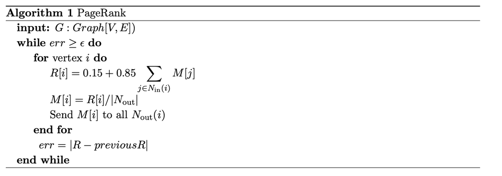

```r
knitr::include_graphics('/Users/billnunn/Desktop/pagerank.jpg')
```

GraphX implements the Pregel viewpoint in Spark using RDDs. It turns out that restricting oneself to the Pregel viewpoint can be limiting, consider the example of calculating the number of connected components of a graph. The Pregel algorithm for this task (assuming each vertex begins with a unique value belonging to a totally ordered set) is for each vertex to spread it’s value to each of it’s neighbours, and update it’s value to minimum of it’s previous value and the values received from other nodes. Eventually each node belonging to a distinct connected component will have the same (minimum and unique to the component) value and the computation can halt. The problem with this algorithm is that it can be very slow on graphs with a large diameter. With order vertex count supersteps for the cycle graph for example.

#### 3.2 Insider Risk Algorithm

Our insider risk algorithm only takes into account the personality scores of each node and the immediate neighbours in the friendship graph, it therefore very likely fits nicely into the Pregel framework, and will probably work very similarly to page rank.

#### Sources

https://spark.apache.org/docs/latest/graphx-programming-guide.html

https://graphframes.github.io/graphframes/docs/_site/user-guide.html

https://www.youtube.com/watch?v=NmbKst7ny5Q

https://www.youtube.com/watch?v=76LOOORaKBU